# Plotting in R

matthias.kuhn@tu-dresden.de

October 9, 2023 <sub>[d8bb58a]</sub>

Plots and graphics that visualize data is one of the areas where R is strong. Actually, there are two major ways to produce graphics in R and we will demonstrate both ways using an example data set.

To demonstrate R’s plotting capabilities we will use a dataset on diamonds that ships with the `ggplot2`-package. Because the data set is so comprehensive we first randomly *sub-sample* 20 diamonds from each group defined by colour and cut quality and store the result under a new name `diam`. For this task, we use the `dplyr`-package. To have reproducible results from the sub-sampling we set the seed of the pseudo random-generator via `set.seed`. The resulting dataframe `diam` should contain 700 rows as we have 35 groups of diamonds in terms of colour and cut quality.

```r
set.seed(1289)   # for reproducible results

# load diamonds data set from package "ggplot2"
# if not installed yet on your computer install once via:
# install.packages("ggplot2")
data(diamonds, package = "ggplot2")

diam <- diamonds |>
  # randomly sample 20 observations per group defined by color & cut
  dplyr::slice_sample(n = 20, by = c(color, cut)) # sub-sampling with dplyr
```

# 1 Base graphics

From its early days on, R has provided quite impressive plotting capabilities built-in. These plot-routines are known as **base-graphic**s. Most of these graphic functions reside in its internal `graphics`-package that is loaded automatically in every R session. Examples are the functions

- `barplot` for a barplot
- `boxplot` for a boxplot
- `plot` for scatter plots

We show two base graphics examples that relate price to certain properties of the diamonds.

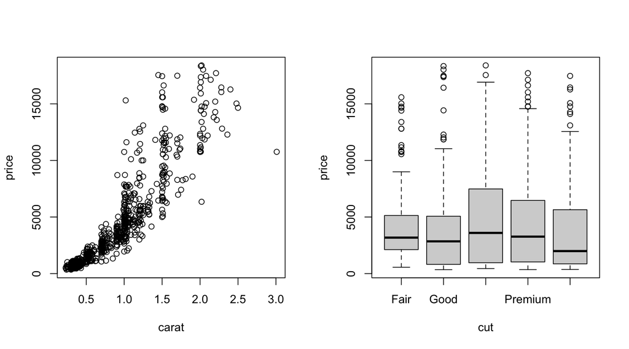

```r
# left: scatter plot price (y-axis) versus carat (x-axis)
plot(price ~ carat, data = diam)
# right: boxplot price (y-axis) versus cut (x-axis)
boxplot(price ~ cut, data = diam)
```

There are a lot of common features shared by (most of) these base graphic functions.

- Most notably, there is the *formula*-interface (like `y ~ x, data = <dataframe>`) with which one specifies the variables of a dataframe to plot on the y- and the x-axis. When a dataframe is provided via the `data=` parameter then you can directly use the column names unquoted (as if they were known variables in the R-session). The R interpreter will first look inside the given dataframe to find matching columns.
- Furthermore, many base plot functions share common argument names like `pch=` (for plot character) or `lty=` (for line type).

Still, the base graphics system has grown slowly over time and can be quite confusing and diverse, lacking an overarching design. You have to explicitly request (i.e. to program) each feature (like a legend or which line type) you want to see on the plot.

# 2 `ggplot2` graphics

In contrast, the add-on R-package `ggplot2` was created by Hadley Wickham more than ten years after the inception of R to facilitate a coherent system to more *declaratively* create graphics. `ggplot2` builds on the idea that a statistical graphic in essence maps the data to the aesthetic attributes (like colour, shape or size) of geometric objects (like points, lines or bars).

> You provide the data, tell `ggplot2` how to map variables to aesthetics, what graphical primitives to use, and it takes care of the details.

> – Paraphrased from [`ggplot2`’s website](https://ggplot2.tidyverse.org/#usage)

Like the R-package `dplyr` for data manipulation, `ggplot2` belongs to the so-called *tidyverse*, a cosmos of R-packages that have a common approach and a similar «feel». In this course, we **prefer to use `ggplot2`** over R’s base graphic functions.

As usually with add-on R-packages you need to install `ggplot2` *once* for your R-software on your computer.

```r
install.packages("ggplot2")
```

Upon starting a new R-session you *load* the package so that all functions of `ggplot2` are directly accessible.

```r
library("ggplot2")
```

Otherwise, you will need to qualify each call to a `ggplot2`-function with `ggplot2::`, e.g., you would need to write `ggplot2::aes()` instead of simply `aes()`.

Here in our primer, we start with a general explanation. Please read on even if it is not immediately clear what it means. The examples at the end hopefully help clarify the concepts. Finally, please play with the code yourself on your computer!

## 2.1 Big picture

Function calls in `ggplot` can become quite verbose but there is a general pattern that the `ggplot2`-authors succinctly describe as

> «In most cases, you start with `ggplot()` and supply a dataset and aesthetic mapping (with `aes()` to parameter `mapping=`). You then add on
> - layers (like `geom_point()` or `geom_histogram()`),
> - scales (like `scale_colour_brewer()`),
> - faceting specifications (like `facet_wrap()`) *and*
> - coordinate systems (like `coord_flip()`).»

> – cited from https://ggplot2.tidyverse.org/#usage

The two most important steps in this scheme are:

1. the **aesthetic mapping** that links data columns to plot properties
2. the **geometric layers** that specify what type of plot you want

### 2.1.1 Mapping

The **aesthetic mapping** specifies which data columns correspond to what property in the plot. The mapping is constructed via a call to `aes` and given as parameter `mapping=` of the function call `ggplot`. For instance, for a scatterplot you need to specify which columns in the dataframe are mapped to the x- and y-axis. In the context of diamond data, one example would be `mapping=aes(x = carat, y = price)`. Besides `x=` and `y=` for 2D-coordinates, other important aesthetics in a plot that can be mapped to data columns are

- `colour=` that governs the colour of points, lines or areas.
- `shape=` that governs the shape of points
- `size=` that dictates the size of points
- `group=` that indicates which observations belong together and form a sub-group

### 2.1.2 Layers

A layer describes how observations are rendered in the plot. In `ggplot2`, layers are created with function calls that start with `geom_` For instance, a call to `geom_point()` yields a layer that will visualize observations as points in a 2D-space with x- and y-coordinates. `geom_histogram()` will create bins for a metric variable and count occurrences in the data and draw bars. Every aesthetic property of a plot that is not data-dependent but should get a specific value can be set within the `geom_` function, for instance, `geom_point(colour = "red")` will draw red points at the coordinates specified in the dataframe.

A single plot can consist of multiple layers. Each layer is «added» to the `ggplot` object and it is natural to do this in a pipeline. The pipeline operator in `ggplot2` is the plus sign `+`. So, with `+`, you literally «add» layer atop layer in a ggplot object.

It is easy to get confused with R’s native pipeline operator `|>` (since R version 4.1) or with `dplyr`’s pipeline operator `%>%` but eventually you might get used to the friendly coexistence of `|>` and `+`, eventually.